# stockX_analysis_1

Anson

2023-06-03

#Load in Data Frame, using read.csv(), and here() fucntion

```r
stockX_data <- read.csv(here("StockX-Data-Contest-2019-3.csv"))
```

#Find unique values of Brand column in df, using unique() function

```r
unique(stockX_data$Brand)
```

```
## [1] " Yeezy"    "Off-White"
```

#Find number of unique values in brand column, using table() function

```r
table(stockX_data$Brand)
```

```
##
##     Yeezy Off-White
##     72162     27794
```

#Select Yeezy 350 models by index using the grep() function, grep returns the index. Select 350 by using splice() fucntion with the saved index Yeezy_350

```r
Yeezy_350 <- grep("350", stockX_data$Sneaker.Name)

stockX_data <- stockX_data %>%
  slice(Yeezy_350)

tail(stockX_data) #checks to see if last obsv contain 350
```

```
##       Order.Date  Brand                                Sneaker.Name Sale.Price
## 72157    2/13/19  Yeezy adidas-Yeezy-Boost-350-V2-Static-Reflective       $582
## 72158    2/13/19  Yeezy adidas-Yeezy-Boost-350-V2-Static-Reflective       $565
## 72159    2/13/19  Yeezy adidas-Yeezy-Boost-350-V2-Static-Reflective       $598
## 72160    2/13/19  Yeezy adidas-Yeezy-Boost-350-V2-Static-Reflective       $605
## 72161    2/13/19  Yeezy adidas-Yeezy-Boost-350-V2-Static-Reflective       $650
## 72162    2/13/19  Yeezy adidas-Yeezy-Boost-350-V2-Static-Reflective       $640
##       Retail.Price Release.Date Shoe.Size Buyer.Region
## 72157         $220     12/26/18      10.0   New Jersey
## 72158         $220     12/26/18       8.0       Oregon
## 72159         $220     12/26/18       8.5   California
## 72160         $220     12/26/18       5.5     New York
## 72161         $220     12/26/18      11.0   California
## 72162         $220     12/26/18      11.5        Texas
```

#Use unique() fucntion and table() fucntion to check which 350 models are in the df

```r
unique(stockX_data$Sneaker.Name)
```

```
##  [1] "Adidas-Yeezy-Boost-350-Low-V2-Beluga"
##  [2] "Adidas-Yeezy-Boost-350-V2-Core-Black-Copper"
##  [3] "Adidas-Yeezy-Boost-350-V2-Core-Black-Green"
##  [4] "Adidas-Yeezy-Boost-350-V2-Core-Black-Red"
##  [5] "Adidas-Yeezy-Boost-350-V2-Core-Black-Red-2017"
##  [6] "Adidas-Yeezy-Boost-350-V2-Core-Black-White"
##  [7] "Adidas-Yeezy-Boost-350-V2-Cream-White"
##  [8] "Adidas-Yeezy-Boost-350-V2-Zebra"
##  [9] "Adidas-Yeezy-Boost-350-Low-Moonrock"
## [10] "Adidas-Yeezy-Boost-350-Low-Pirate-Black-2016"
## [11] "Adidas-Yeezy-Boost-350-Low-Oxford-Tan"
## [12] "Adidas-Yeezy-Boost-350-Low-Turtledove"
## [13] "Adidas-Yeezy-Boost-350-Low-Pirate-Black-2015"
## [14] "Adidas-Yeezy-Boost-350-V2-Semi-Frozen-Yellow"
## [15] "Adidas-Yeezy-Boost-350-V2-Beluga-2pt0"
## [16] "Adidas-Yeezy-Boost-350-V2-Blue-Tint"
## [17] "adidas-Yeezy-Boost-350-V2-Butter"
## [18] "Adidas-Yeezy-Boost-350-V2-Sesame"
## [19] "adidas-Yeezy-Boost-350-V2-Static"
## [20] "adidas-Yeezy-Boost-350-V2-Static-Reflective"
```

```r
table(stockX_data$Sneaker.Name)
```

```
##
##           Adidas-Yeezy-Boost-350-Low-Moonrock
##                                           100
##         Adidas-Yeezy-Boost-350-Low-Oxford-Tan
##                                            70
##  Adidas-Yeezy-Boost-350-Low-Pirate-Black-2015
##                                            95
##  Adidas-Yeezy-Boost-350-Low-Pirate-Black-2016
##                                           122
##         Adidas-Yeezy-Boost-350-Low-Turtledove
##                                            68
##          Adidas-Yeezy-Boost-350-Low-V2-Beluga
##                                           498
##         Adidas-Yeezy-Boost-350-V2-Beluga-2pt0
##                                         10395
##           Adidas-Yeezy-Boost-350-V2-Blue-Tint
##                                          9297
##              adidas-Yeezy-Boost-350-V2-Butter
##                                         11423
##   Adidas-Yeezy-Boost-350-V2-Core-Black-Copper
##                                           225
##    Adidas-Yeezy-Boost-350-V2-Core-Black-Green
##                                           196
##      Adidas-Yeezy-Boost-350-V2-Core-Black-Red
##                                           302
## Adidas-Yeezy-Boost-350-V2-Core-Black-Red-2017
##                                           969
##    Adidas-Yeezy-Boost-350-V2-Core-Black-White
##                                           621
##         Adidas-Yeezy-Boost-350-V2-Cream-White
##                                          9097
##  Adidas-Yeezy-Boost-350-V2-Semi-Frozen-Yellow
##                                          4854
##              Adidas-Yeezy-Boost-350-V2-Sesame
##                                          5553
##              adidas-Yeezy-Boost-350-V2-Static
##                                          4983
##   adidas-Yeezy-Boost-350-V2-Static-Reflective
##                                          3184
##               Adidas-Yeezy-Boost-350-V2-Zebra
##                                         10110
```

#Select relevant columns:[3]Sneaker.Name, [4]Sale.Price, [5]Retail.Price using select() function. Arrnage using arrange() function

```r
stockX_data <- stockX_data %>%
  select(Sneaker.Name, Sale.Price, Retail.Price) %>%
  arrange(Sneaker.Name)
```

#Remove” $ “and” , ” from the sales price and retail price column using gsub() funtion. Convert class of Sales.Price and Retail.Price column. “charachter” to “numeric”.using as.numeric() function

```r
stockX_data$Sale.Price <- gsub("\\$", "", stockX_data$Sale.Price)
stockX_data$Sale.Price <- gsub("\\,", "", stockX_data$Sale.Price)
stockX_data$Retail.Price <- gsub("\\$", "", stockX_data$Retail.Price)

stockX_data$Sale.Price <- as.numeric(stockX_data$Sale.Price)
stockX_data$Retail.Price <- as.numeric(stockX_data$Retail.Price)
```

#Use group_by() function and gorup by Sneaker.Name to refine obersavtions and use summarize() function and sum() function to caluclate total resell price and total retail price

```r
stockX_data <- stockX_data %>%
  group_by(Sneaker.Name) %>%
  summarize(Total.Resell.Price = sum(Sale.Price), Total.Retail.Price = sum(Retail.Price))
```

#Graph of Total Resell Price using geom_col()

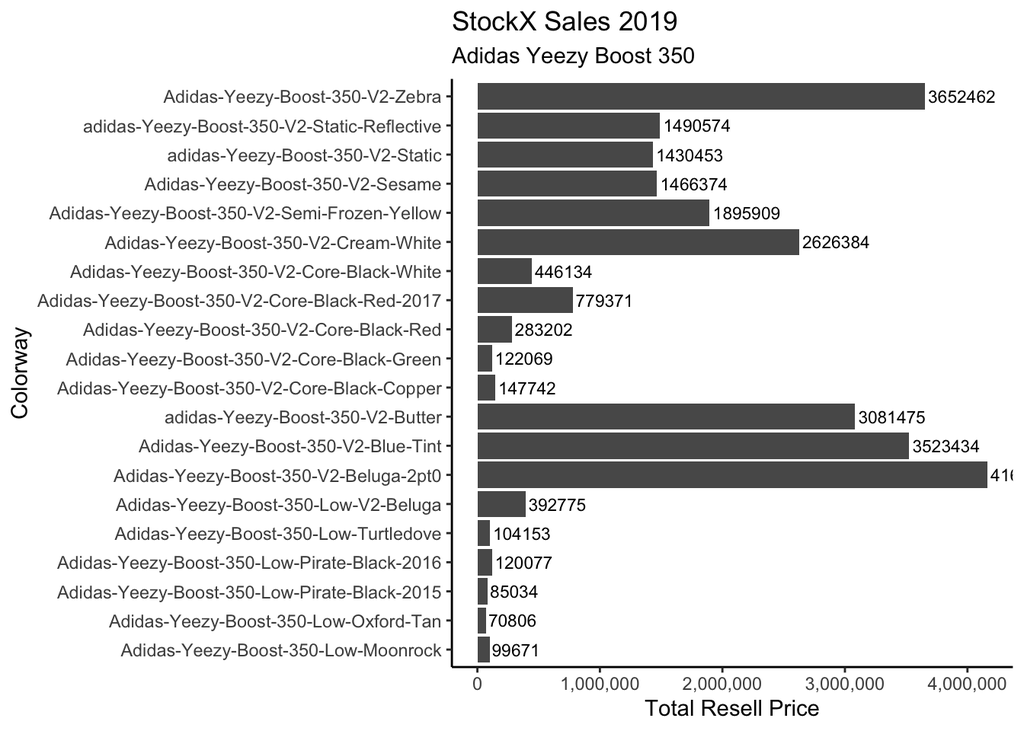

```r
stockX_resell_graph_350 <- ggplot(data = stockX_data, aes(Sneaker.Name, Total.Resell.Price))+
  geom_col() +
  theme_classic()+
  coord_flip() +
  scale_y_continuous(labels = scales::comma_format()) +
  geom_text(aes(label = Total.Resell.Price), hjust = -0.05, size = 3)+
  labs(y = "Total Resell Price", x = "Colorway", title = "StockX Sales 2019", subtitle = "Adidas Yeezy Boost 350")

stockX_resell_graph_350
```

#Graph of Total Retail Price using geom_col()

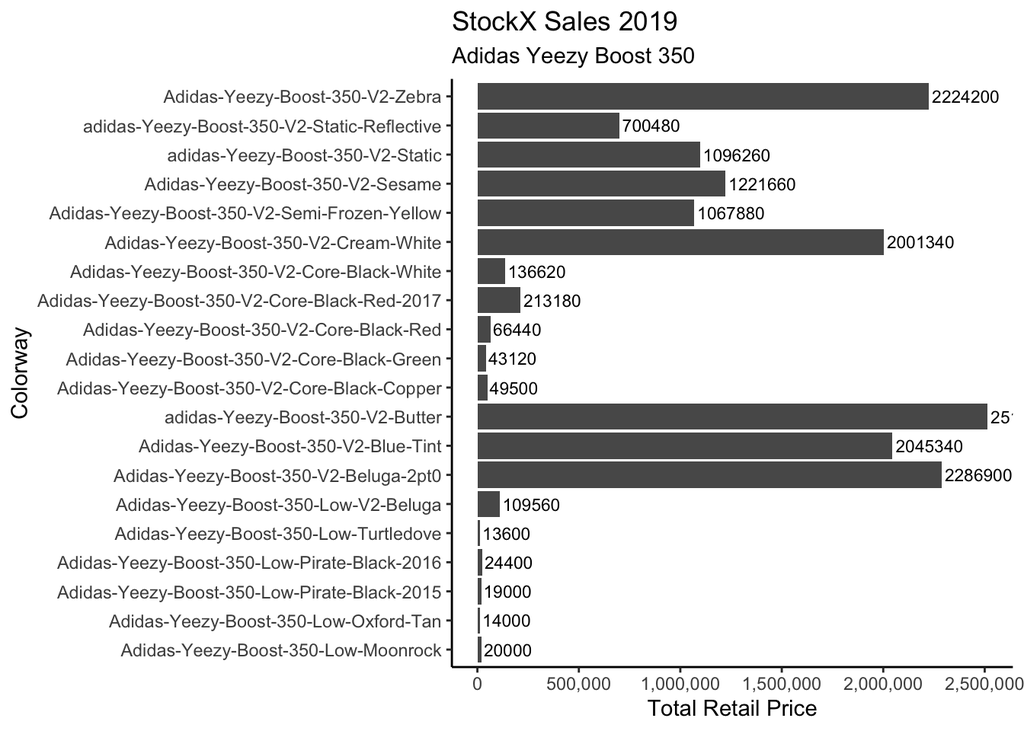

```r
stockX_retail_graph_350 <- ggplot(data = stockX_data, aes(Sneaker.Name, Total.Retail.Price))+
  geom_col() +
  theme_classic()+
  coord_flip() +
  scale_y_continuous(labels = scales::comma_format()) +
  geom_text(aes(label = Total.Retail.Price), hjust = -0.05, size = 3)+
  labs(y = "Total Retail Price", x = "Colorway", title = "StockX Sales 2019", subtitle = "Adidas Yeezy Boost 350")

stockX_retail_graph_350
```

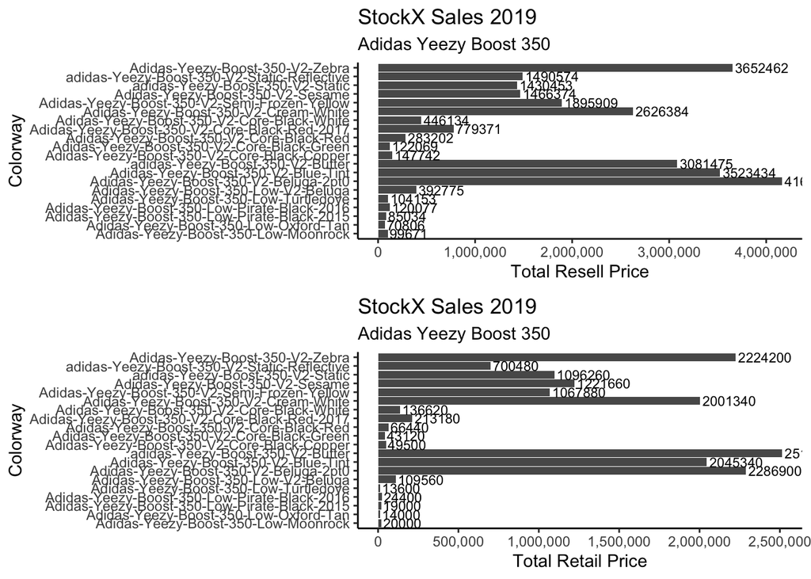

```r
grid.arrange(stockX_resell_graph_350, stockX_retail_graph_350, ncol = 1)
```